# Classification

In your second homework you need to create a model that predicts which passengers survived the Titanic shipwreck.

```python
import pandas as pd
train_df=pd.read_csv('train.csv')
test_df=pd.read_csv('test.csv')
```

# Data exploration

We check the shape of train and test dataframes and also show a selection of rows, to have an initial understanding of the data.

```python
train_df.sample(5).head()
```

|  | PassengerId | Survived | Pclass | Name | Sex | Age | SibSp | Parch | Ticket | Fare | Cabin | Embarked |
| --- | --- | --- | --- | --- | --- | --- | --- | --- | --- | --- | --- | --- |
| 741 | 742 | 0 | 1 | Cavendish, Mr. Tyrell William | male | 36.00 | 1 | 0 | 19877 | 78.8500 | C46 | S |
| 852 | 853 | 0 | 3 | Boulos, Miss. Nourelain | female | 9.00 | 1 | 1 | 2678 | 15.2458 | NaN | C |
| 644 | 645 | 1 | 3 | Baclini, Miss. Eugenie | female | 0.75 | 2 | 1 | 2666 | 19.2583 | NaN | C |
| 495 | 496 | 0 | 3 | Yousseff, Mr. Gerious | male | NaN | 0 | 0 | 2627 | 14.4583 | NaN | C |
| 163 | 164 | 0 | 3 | Calic, Mr. Jovo | male | 17.00 | 0 | 0 | 315093 | 8.6625 | NaN | S |

```python
test_df.sample(5).head()
```

|  | PassengerId | Pclass | Name | Sex | Age | SibSp | Parch | Ticket | Fare | Cabin | Embarked |
| --- | --- | --- | --- | --- | --- | --- | --- | --- | --- | --- | --- |
| 212 | 1104 | 2 | Deacon, Mr. Percy William | male | 17.0 | 0 | 0 | S.O.C. 14879 | 73.500 | NaN | S |
| 204 | 1096 | 2 | Andrew, Mr. Frank Thomas | male | 25.0 | 0 | 0 | C.A. 34050 | 10.500 | NaN | S |
| 43 | 935 | 2 | Corbett, Mrs. Walter H (Irene Colvin) | female | 30.0 | 0 | 0 | 237249 | 13.000 | NaN | S |
| 362 | 1254 | 2 | Ware, Mrs. John James (Florence Louise Long) | female | 31.0 | 0 | 0 | CA 31352 | 21.000 | NaN | S |
| 45 | 937 | 3 | Peltomaki, Mr. Nikolai Johannes | male | 25.0 | 0 | 0 | STON/O 2. 3101291 | 7.925 | NaN | S |

```python
print("Train: rows:{} cols:{}".format(train_df.shape[0], train_df.shape[1]))
print("Test:  rows:{} cols:{}".format(test_df.shape[0], test_df.shape[1]))
```

```
Train: rows:891 cols:12
Test:  rows:418 cols:11
```

```python
# Importing libraries
import pandas as pd
import numpy as np
import seaborn as sns
from matplotlib import pyplot as plt
from sklearn.metrics import accuracy_score, log_loss
from sklearn.tree import DecisionTreeClassifier
from sklearn.ensemble import RandomForestClassifier
from sklearn.model_selection import train_test_split
from sklearn.model_selection import cross_validate
from sklearn.model_selection import cross_val_score
from sklearn.model_selection import cross_val_predict
from sklearn.metrics import confusion_matrix
from sklearn.model_selection import GridSearchCV, KFold
from sklearn.exceptions import FitFailedWarning
import warnings
warnings.simplefilter(action='ignore', category=FutureWarning)

class TitanicSurvivalPredictor:
    def __init__(self, colab_compability):
        self.colab = colab_compability
        self.load_data()

        # Setting up visualisations
        sns.set_style(style='white')
        sns.set(rc={
            'figure.figsize':(12,7),
            'axes.facecolor': 'white',
            'axes.grid': True, 'grid.color': '.9',
            'axes.linewidth': 1.0,
            'grid.linestyle': u'-'},font_scale=1.5)
        custom_colors = ["#3498db", "#95a5a6","#34495e", "#2ecc71", "#e74c3c"]
        sns.set_palette(custom_colors)

    def load_data(self):
        "in the google colab is used different path"
        if self.colab:
            trd = pd.read_csv('train.csv')
            tsd = pd.read_csv('train.csv')
        else:
            trd = pd.read_csv('train.csv')
            tsd = pd.read_csv('test.csv')
        self.td = pd.concat([trd, tsd], ignore_index=True, sort  = False)

    def data_info(self):
        print("#"*80)
        # The data contains 1309 rows and 12 colunmns. Each row signifies a human on the deck and each column is an attribute corresponding to that huma
        print(self.td.shape)
        print("#"*80)
        # On diving deeper in to the columns, we see five integer type columns, five object types (strings) and two columns with decimal values. Also, all the columns do not have 1309 values which indicates that there are missing values.
        print(self.td.info())
        print("#"*80)
        # Check any unique value in the dataset are unique or not
        print(self.td.nunique())
        print("#"*80)

    def heat_map(self):
        '''Missing vaues distribution in our dataset'''
        sns.heatmap(self.td.isnull(), cbar = False).set_title("Missing values heatmap")
        plt.show()

    def check_missing_value(self):
        '''
        The line plot and the heat map below show the number of missing values in all columns. There are multiple columns that have missing values
        - Age
        - Cabin
        - Embarked
        - Fare
        - Survived

        77.5% of data is NOT available for the column 'Cabin'. Hence, it can be dropped in our analysis
        In contrast, Embarked has only 2 missing missing values.
        The column 'Age' on the other hand has 177 missing values which contribute to **20%** on the total expected values.
        Fare has 1 missing value.
        '''
        pd.DataFrame(self.td.isnull().sum()).plot.line().set_title("Number of missing values in the given features")
        print(self.td.isnull().sum())
        plt.show()

    def cheking_gender(self):
        for gender in ["male","female"]:
            for survival_status in [1, 0]: # 1 for survived, 0 for deceased
                df_filtered = self.td[(self.td.Sex == gender) & (self.td.Survived == survival_status)]
                sns.kdeplot(df_filtered.Age, label=f"{gender} {['deceased', 'survived'][survival_status]}")
        plt.title("Training Data - Gender density in classes")
        plt.legend(("Male Deceased", "Male Survived", "Female Deceased", "Female Survived"))
        plt.show()

    def checking_family(self):
        pc = pd.DataFrame()
        pc['survived'] = self.td.Survived
        pc['parents_children'] = pd.cut(self.td.Parch, [0, 1, 2, 3, 4, 5, 6], include_lowest = True) # Number of parents/children and survival density
        # (pc.parents_children.value_counts()).plot.area().set_title("Training Data - Number of parents/children and survival density")
        x = sns.countplot(x = "parents_children", hue = "survived", data = pc, palette=["C1", "C0"]).legend(labels = ["Deceased", "Survived"])
        x.set_title("Training Data - Survival based on number of parents/children")
        plt.show()

    def embarking(self):
        '''
        Embarked signifies where the traveler boarded from.
        70% of the people boarded from Southampton. Just under 20% boarded from Cherbourg and rest from Queenstown
        '''
        p = sns.countplot(x = "Embarked", hue = "Survived", data = self.td, palette=["C1", "C0"])
        p.set_xticklabels(["Southampton","Cherbourg","Queenstown"])
        p.legend(labels = ["Deceased", "Survived"])
        p.set_title("Training Data - Survival based on embarking point.")
        plt.show()

    def data_preprocessing(self, dataframe, debug):
        '''
        1 new feature that could be created is FamilySize, which is a combination of
        SibSp (Number of siblings/spouses aboard) and Parch (Number of parents/children aboard).
        This new feature could provide additional insight into whether passengers with family members
        were more or less likely to survive the Titanic disaster
        '''
        # Check 'Survived' are in the dataframe or not
        try:
            # If the Survived column is missing, it likely means that the passenger did not survive
            # Fill missing values in Survived with 0
                dataframe['Survived'].fillna(0, inplace=True)
        except:
            pass
        # Fill missing values in Age with the median age
        dataframe['Age'].fillna(dataframe['Age'].median(), inplace=True)
        # Drop the Cabin column because 77.5% of data is NOT available
        dataframe = dataframe.drop(['Cabin'], axis=1)
        # Fill missing values in Embarked with the most common Embarkation point
        dataframe['Embarked'].fillna(dataframe['Embarked'].mode()[0], inplace=True)
        # Fill missing values in Fare with the median fare
        dataframe['Fare'].fillna(dataframe['Fare'].median(), inplace=True)
        # Convert categorical variables to numerical form
        dataframe = pd.get_dummies(dataframe, columns=['Sex', 'Embarked'])
        # Drop unnecessary columns
        dataframe = dataframe.drop(['Name', 'Ticket', 'PassengerId'], axis=1)

        # add feature
        dataframe['FamilySize'] = dataframe['SibSp'] + dataframe['Parch'] + 1

        # Check if any data are missing or not
        if debug:
            self.check_missing_value()
            print("#"*80)
            self.heat_map()

        return dataframe

    def DecisionTree_training(self, tuning, matrix_score):
        self.td = self.data_preprocessing(self.td, debug = False)

        # Split the data into features and labels
        X = self.td.drop('Survived', axis=1)
        y = self.td['Survived']

        # Split the data into training and testing sets
        X_train, X_test, y_train, y_test = train_test_split(X, y, test_size=0.2)

        if tuning:
            # Grid search for hyperparameter tuning
            param_grid = {'max_depth': np.arange(1, 10)}
            tree = GridSearchCV(DecisionTreeClassifier(), param_grid, cv=KFold(n_splits=5))
            tree.fit(X_train, y_train)
            print("Best parameters for Decision Tree: ", tree.best_params_)
            self.clf = DecisionTreeClassifier(**tree.best_params_)
        else:
            self.clf = DecisionTreeClassifier()
        self.clf.fit(X_train, y_train)

        if matrix_score:
            self.confusion_matrix(X_train, y_train, X_test, y_test)

    def RandomForest_training(self, tuning, matrix_score):
        self.td = self.data_preprocessing(self.td, debug = False)

        # Split the data into features and labels
        X = self.td.drop('Survived', axis=1)
        y = self.td['Survived']

        # Split the data into training and testing sets
        X_train, X_test, y_train, y_test = train_test_split(X, y, test_size=0.2)

        if tuning:
            # Grid search for hyperparameter tuning
            param_grid = {'n_estimators': [100, 200, 300, 400, 500], 'max_features': ['auto', 'sqrt', 'log2']}
            rf = GridSearchCV(RandomForestClassifier(), param_grid, cv=KFold(n_splits=5))
            # Handle FitFailedWarning
            with warnings.catch_warnings():
                warnings.filterwarnings("ignore", category=FitFailedWarning)
                rf.fit(X_train, y_train)
            print("Best parameters for Random Forest: ", rf.best_params_)
            self.clf = RandomForestClassifier(**rf.best_params_)
        else:
            self.clf = RandomForestClassifier()
        self.clf.fit(X_train, y_train)

        if matrix_score:
            self.confusion_matrix(X_train, y_train, X_test, y_test)

    def confusion_matrix(self, X_train, y_train, X_test, y_test):
        # Print the accuracy score
        y_pred = self.clf.predict(X_test)
        print("RF Accuracy: "+repr(round(accuracy_score(y_test, y_pred) * 100, 2)) + "%")
        result_dt=cross_val_score(self.clf,X_train,y_train,cv=10,scoring='accuracy')
        print('The cross validated score for DT is:',round(result_dt.mean()*100,2))

        y_pred = cross_val_predict(self.clf,X_train,y_train,cv=10)
        sns.heatmap(confusion_matrix(y_train,y_pred),annot=True,fmt='3.0f',cmap="summer")
        plt.title('Confusion_matrix for DT', y=1.05, size=15)
        plt.show()

    def predict(self, input_data, model_type):
        # Ensure the input data is a 2D array
        if input_data.ndim == 1:
            input_data = np.expand_dims(input_data, axis=0)



        # Use the chosen model to make predictions
        if model_type == 'DecisionTree' or model_type == 'RandomForest':
            prediction = self.clf.predict(input_data)
        else:
            prediction = None
        return prediction

if __name__ == "__main__":
    colab_compability = True
    hw_class = TitanicSurvivalPredictor(colab_compability)

    # hw_class.data_info()
    # hw_class.heat_map()
    # hw_class.check_missing_value()
    # hw_class.cheking_gender()
    # hw_class.checking_family()
    # hw_class.embarking()
    # hw_class.data_preprocessing(hw_class.td, debug = True)
    # hw_class.DecisionTree_training(tuning=True, matrix_score=True)
    # hw_class.RandomForest_training(tuning=True, matrix_score=True)
```

Both **train** and **test** files contains the following values:

- **PassengerID** - the index of the passenger (in the dataset);
- **PClass** - the class of the passenger (from 1 to 3);
- **Name** - the name of the passenger;
- **Sex** - the sex of the passenger (female or male);
- **Age** - the age (where available) of the passenger;
- **SibSp** - the number of sibilings / spouses aboard of Titanic;
- **Parch** - the number of parents / children aboard of Titanic;
- **Ticket** - the ticket number;
- **Fare** - the passenger fare (ticket cost);
- **Cabin** - the cabin number;
- **Embarked** - the place of embarcation of the passenger (C = Cherbourg, Q = Queenstown, S = Southampton).

The **train** data has as well the target value, **Survived**.

It is important to have a good understanding of the data before going to create a model. Therefore we will explore the features.

Let's start by checking if there are missing data and unlabeled data.

Next, analyze the dependencies of the target variable on various features, such as Age, Sex, and so on, using approaches similar to those in the first homework.

Draw conclusions about what affects whether the passenger survives, check the distribution of features in the train and test data.

```
################################################################################
(1782, 12)
################################################################################
<class 'pandas.core.frame.DataFrame'>
RangeIndex: 1782 entries, 0 to 1781
Data columns (total 12 columns):
 #   Column       Non-Null Count  Dtype
---  ------       --------------  -----
 0   PassengerId  1782 non-null   int64
 1   Survived     1782 non-null   int64
 2   Pclass       1782 non-null   int64
 3   Name         1782 non-null   object
 4   Sex          1782 non-null   object
 5   Age          1428 non-null   float64
 6   SibSp        1782 non-null   int64
 7   Parch        1782 non-null   int64
 8   Ticket       1782 non-null   object
 9   Fare         1782 non-null   float64
 10  Cabin        408 non-null    object
 11  Embarked     1778 non-null   object
dtypes: float64(2), int64(5), object(5)
memory usage: 167.2+ KB
None
################################################################################
PassengerId    891
Survived         2
Pclass           3
Name           891
Sex              2
Age             88
SibSp            7
Parch            7
Ticket         681
Fare           248
Cabin          147
Embarked         3
dtype: int64
################################################################################
################################################################################
```

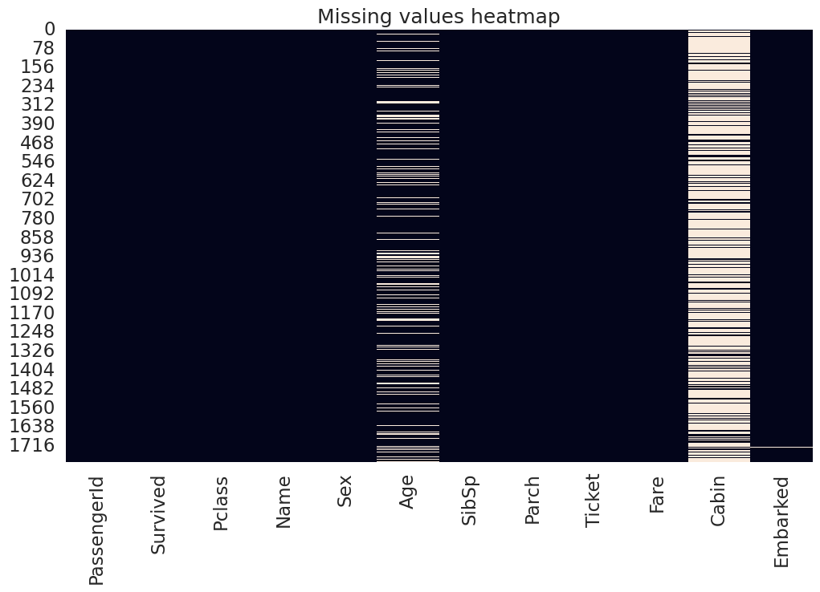

```
################################################################################
PassengerId       0
Survived          0
Pclass            0
Name              0
Sex               0
Age             354
SibSp             0
Parch             0
Ticket            0
Fare              0
Cabin          1374
Embarked          4
dtype: int64
```

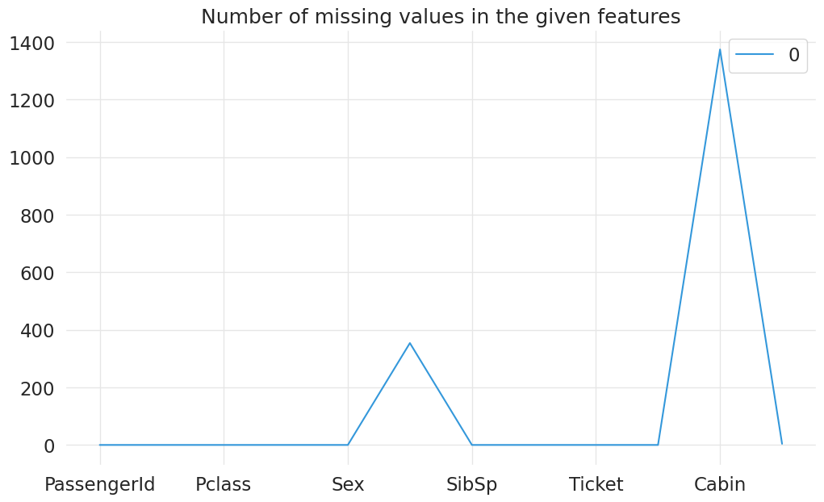

```
################################################################################
```

[figure not shown]

```
################################################################################
```

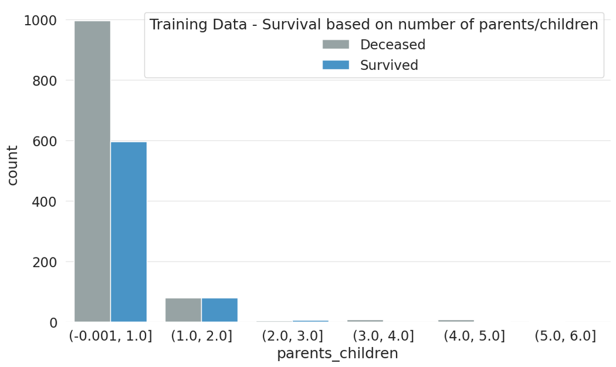

```
################################################################################
```

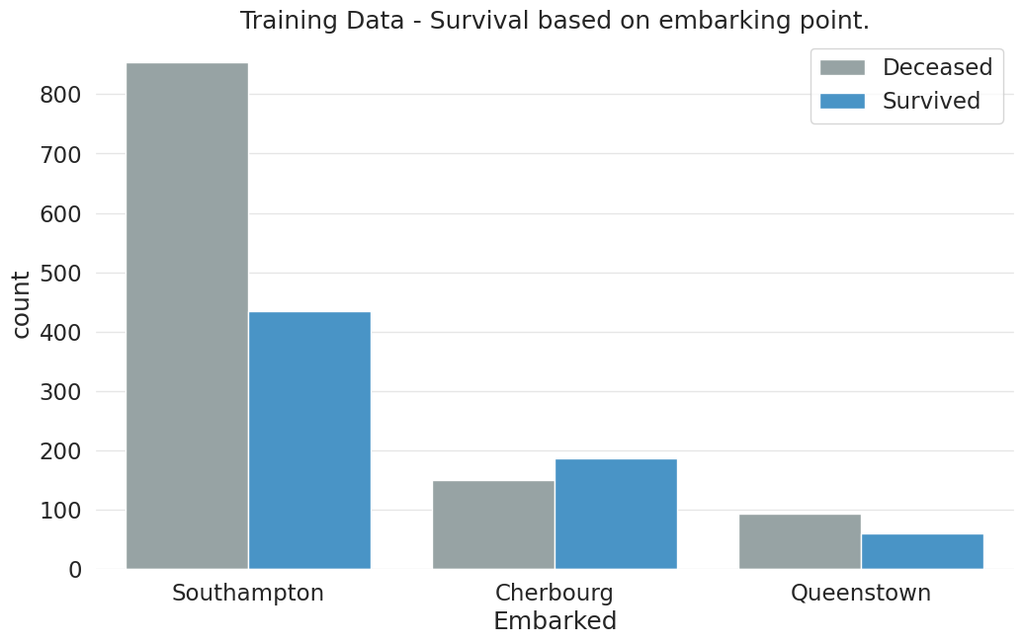

```
################################################################################
```

```python
hw_class = TitanicSurvivalPredictor(colab_compability=True)
hw_class.data_info()
print("#"*80)
hw_class.heat_map()
print("#"*80)
hw_class.check_missing_value()
print("#"*80)
hw_class.cheking_gender()
print("#"*80)
hw_class.checking_family()
print("#"*80)
hw_class.embarking()
print("#"*80)
```

## Split the data

Let's split the training and validation set. We will use a 80-20 split. Don't forget to fix random_state.

```
Survived      0
Pclass        0
Age           0
SibSp         0
Parch         0
Fare          0
Sex_female    0
Sex_male      0
Embarked_C    0
Embarked_Q    0
Embarked_S    0
FamilySize    0
dtype: int64
```

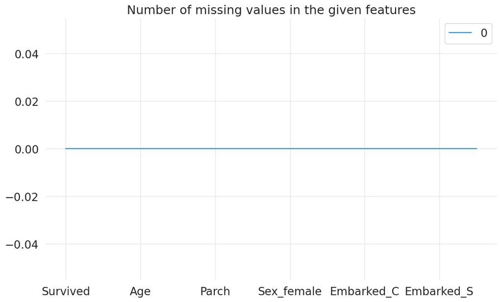

```
################################################################################
```

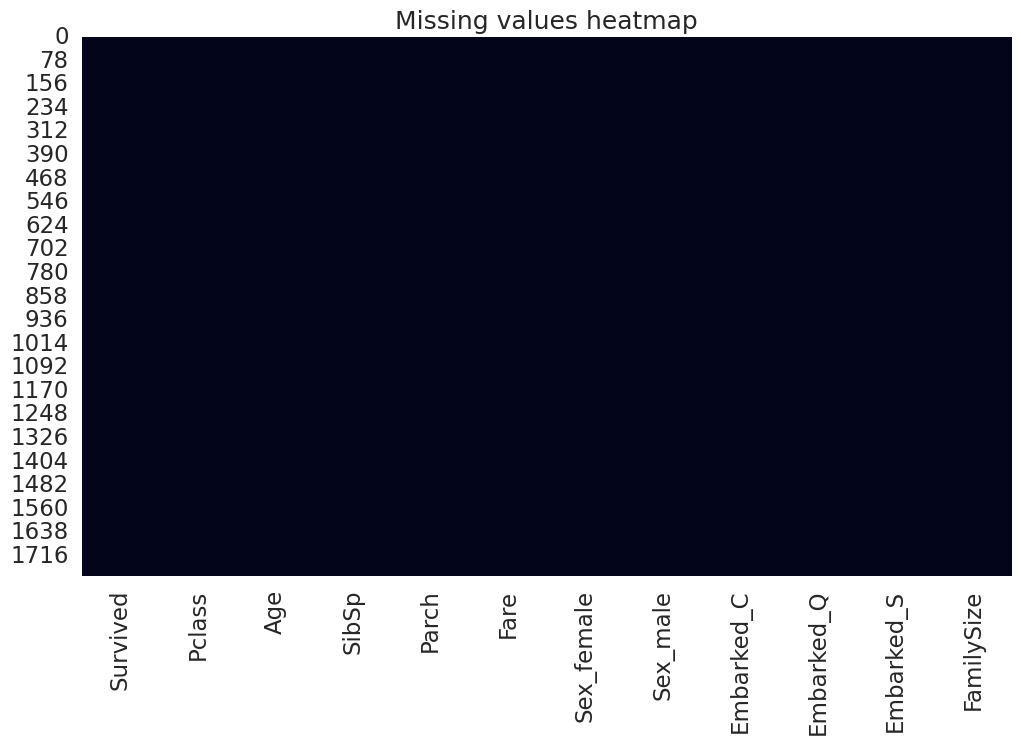

```
################################################################################
```

[output not shown]

```python
# it should be all black, meaning there is no "NAN" data in dataframe
hw_class = TitanicSurvivalPredictor(colab_compability=True)
hw_class.data_preprocessing(debug = True)
print("#"*80)
hw_class.td.head(10)
```

## Build a model

Next, create two more complicated models: DesicionTreeClassifier and RandomForestClassifier with adding at least one feature you found useful as a result of your analysis.

Find accuracy score for all models. Is it a good idea to use accuracy? Any suggestions about metrics?

Then try to tune at least one parameter for every model using grid search and write down features and parameters, which gave you best score.

## Decision tree

[output not shown]

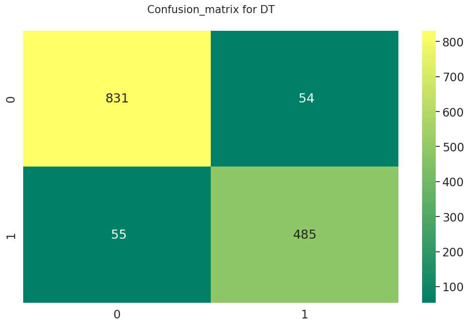

```python
# DecisionTree no tune
hw_class = TitanicSurvivalPredictor(colab_compability=True)
hw_class.DecisionTree_training(tuning=False, matrix_score=True)
```

[output not shown]

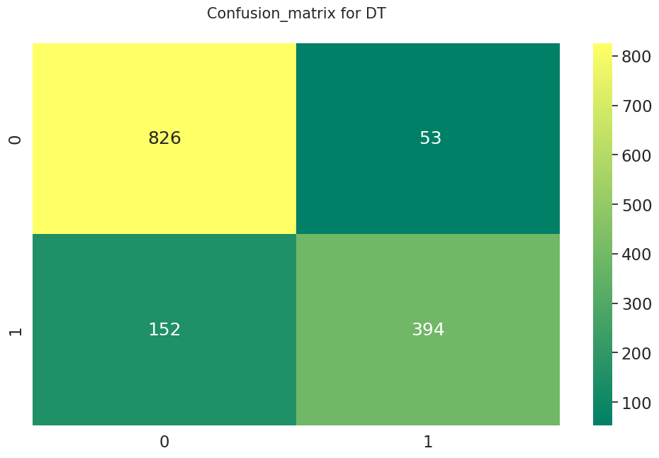

```python
# DecisionTree fine tune
# some times the fine-tuned version produce worse result that the default model
hw_class = TitanicSurvivalPredictor(colab_compability=True)
hw_class.DecisionTree_training(tuning=True, matrix_score=True)
```

## Random Forest

[output not shown]

[figure not shown]

```python
# RandomForest no tune
hw_class = TitanicSurvivalPredictor(colab_compability=True)
hw_class.RandomForest_training(tuning=False, matrix_score=True)
```

[output not shown]

[figure not shown]

```python
# RandomForest fine tune
# some times the fine-tuned version produce worse result that the default model
hw_class = TitanicSurvivalPredictor(colab_compability=True)
hw_class.RandomForest_training(tuning=True, matrix_score=True)
```

### Predict

```python
    test = pd.read_csv('test.csv')
    test = pd.concat([test], ignore_index=True, sort  = False)
    test_df = hw_class.data_preprocessing(test, debug = False)
    hw_class.DecisionTree_training(tuning=False, matrix_score=False)
    output = hw_class.predict(test_df, model_type='DecisionTree')
    test["Survival_chance"] = output
    print(test)
```

[output not shown]